# KIDM - Marketing - Datensatz

### Month-Variable

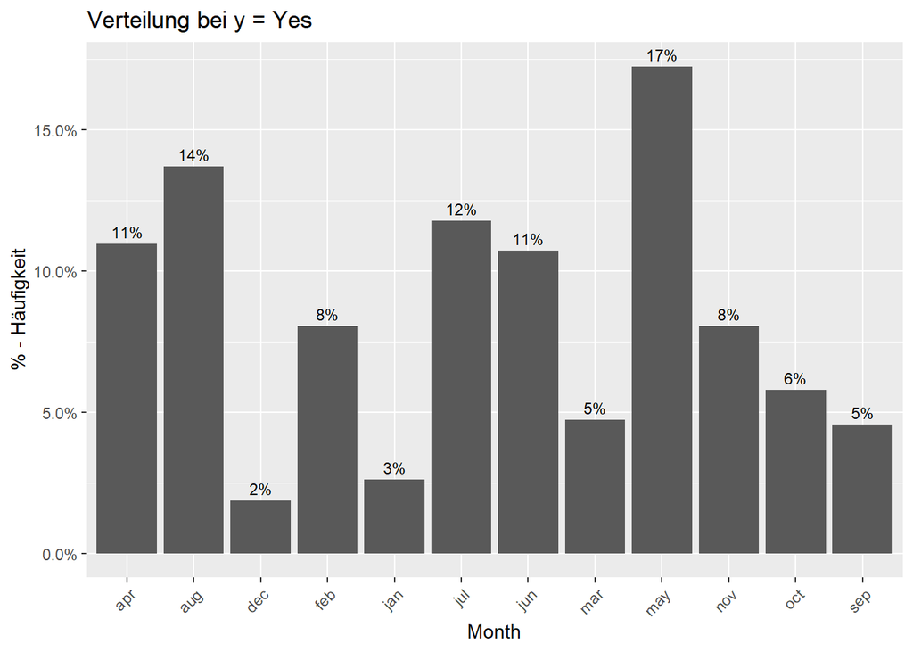

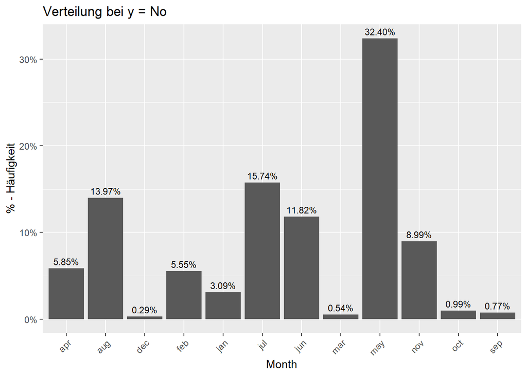

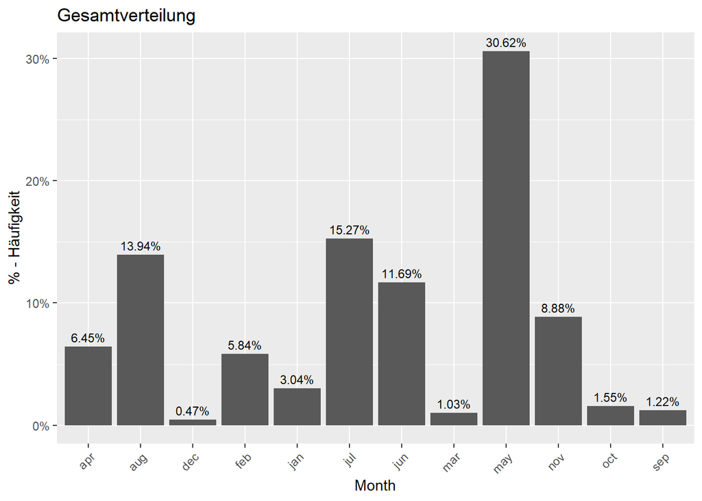

Der Monat Mai scheint sehr beliebt zu sein um zu Werben.

### Day-Variable

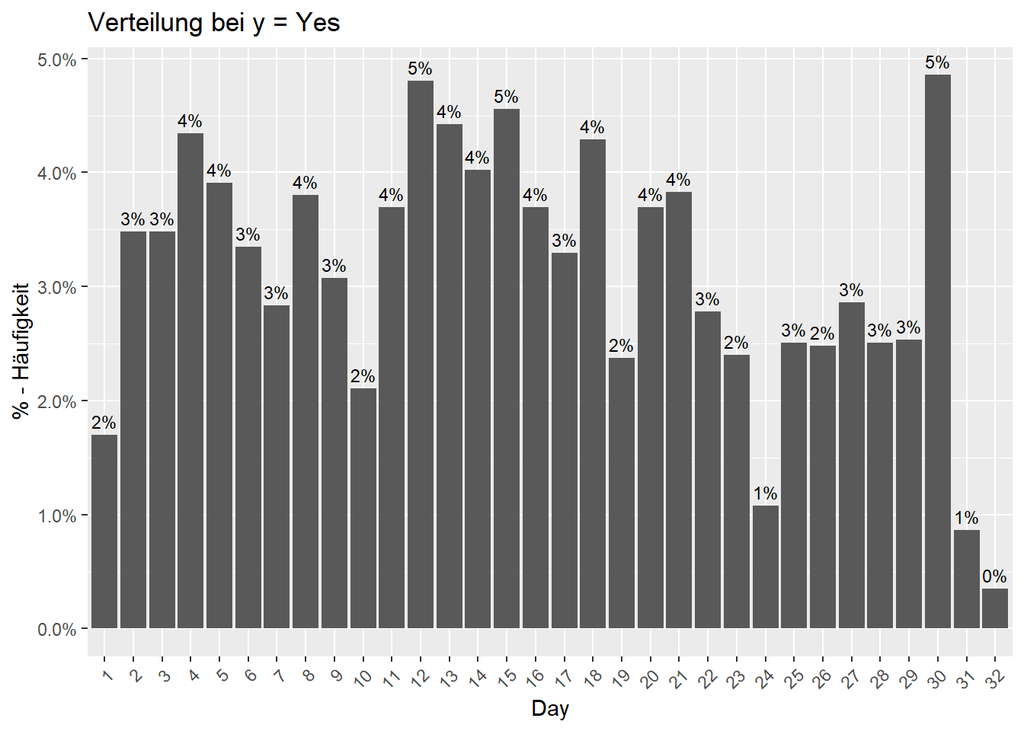

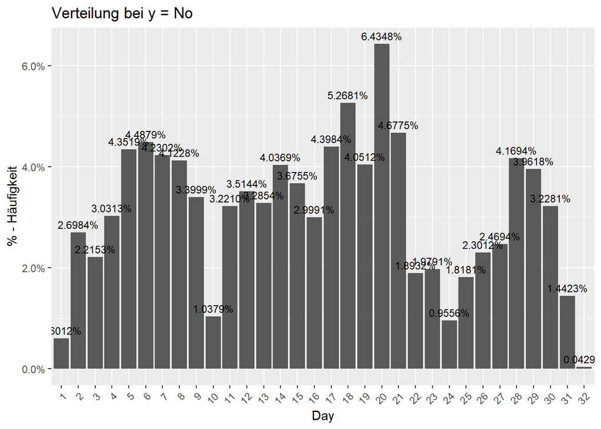

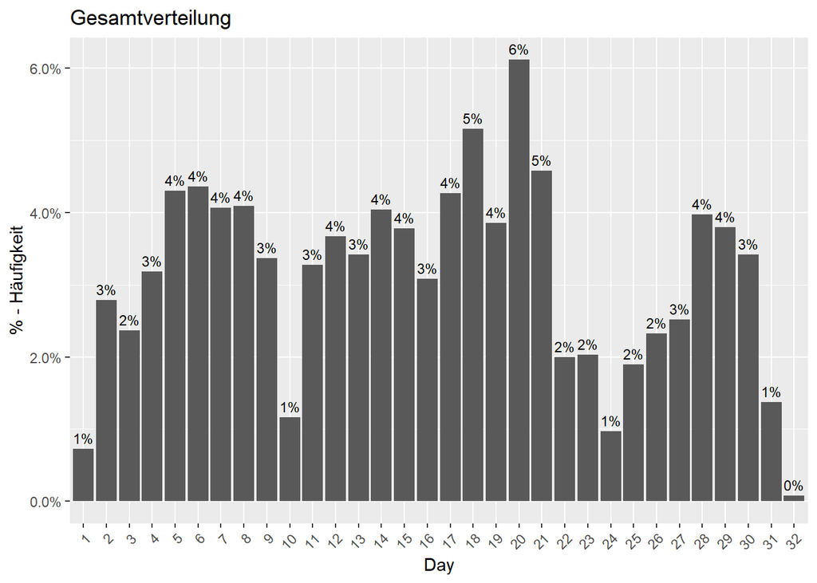

Der Tag scheint keinen großen einfuss zu haben. Jedoch laut unseres Datensatzes hat ein Monat 32 Tage. Analyse der 32. Tage.

```
##    age       job  marital education default balance housing loan   contact day
## 1  195   retired   single   primary      no    1965      no   no telephone  32
## 2  109 housemaid divorced   primary      no    1381      no   no  cellular  32
## 3  183   retired divorced   primary      no       0      no   no telephone  32
## 4  174   retired  married      <NA>      no    1934      no   no telephone  32
## 5  148   retired divorced   primary      no       0      no   no telephone  32
## 6  129   retired  married   primary      no    8603      no   no  cellular  32
## 7  153   retired  married  tertiary      no    6236      no   no  cellular  32
## 8  157   retired  married   primary      no     648      no   no telephone  32
## 9  184 housemaid divorced   primary      no    5944      no   no  cellular  32
## 10 121   retired divorced      <NA>      no       0      no   no telephone  32
## 11 187   retired divorced   primary      no      20      no   no  cellular  32
## 12 136   retired  married secondary      no     276      no   no telephone  32
## 13 163   retired  married   primary      no    2190      no   no telephone  32
## 14 196   retired  married   primary      no     425      no   no telephone  32
```

[output cut: 37 more lines]

Scheint nichts weiter ungeöhnlich an den Tagen, deshalb wird der 32. Tag, dem 1. Tag des Montats zugeordnet.

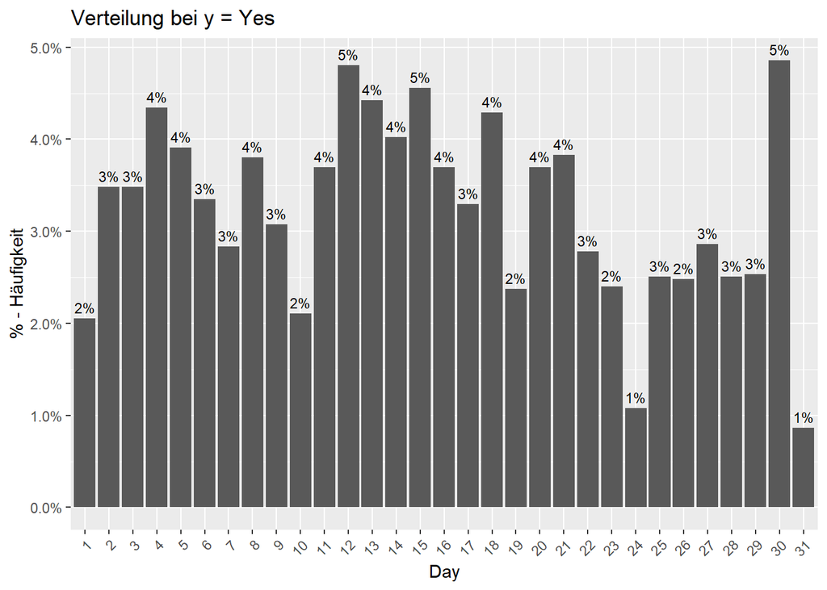

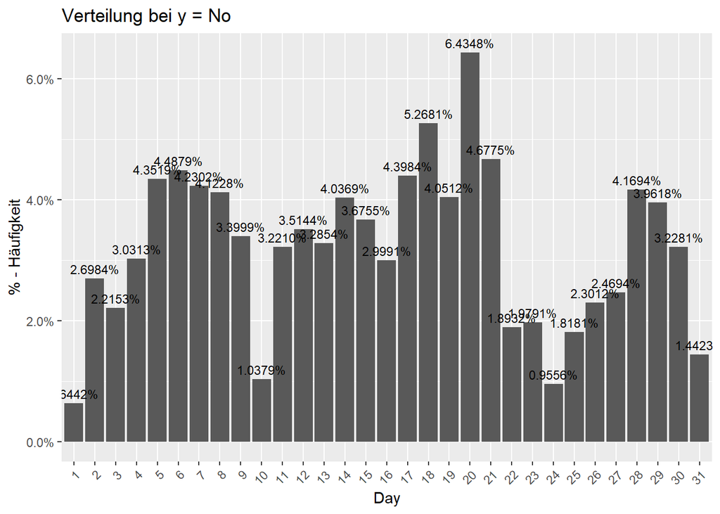

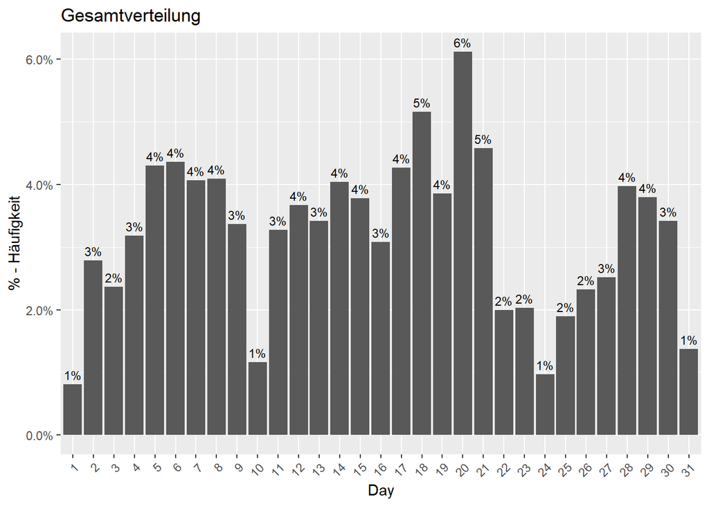

Die Variable scheint nun so weit in Ordnung zu sein.

### Pdays-Variable

```
## [1] "NA-Anteil:"          "0.00309656218402427"
```

```
## [1] "-1-Anteil:"        "0.814206268958544"
```

Es ist nicht sinnvoll, -1 = Niemals; und 0 = gestern in relation zu einander stehen zu lassen. Demzufolge habe ich mittels Binning die Variable von Metrisch auf eine Kategoriale Variable mit 5 leveln abgeändert. Dazu genutzt habe ich die Interquatielsabstände (ohne einfluss aller “-1” Werte) 25, 50, 75 genutzt. < 25% = previosly < 50% = relatively long < 75% = long ago alles andere = very long ago

```
## select(df, --1)
##
##  1  Variables      31648  Observations
## --------------------------------------------------------------------------------
## age
##        n  missing distinct     Info     Mean      Gmd      .05      .10
##    28361     3287       99    0.999    40.98    11.98       27       29
##      .25      .50      .75      .90      .95
##       33       39       48       56       59
##
## lowest :  18  19  20  21  22, highest: 183 184 187 195 196
## --------------------------------------------------------------------------------
```

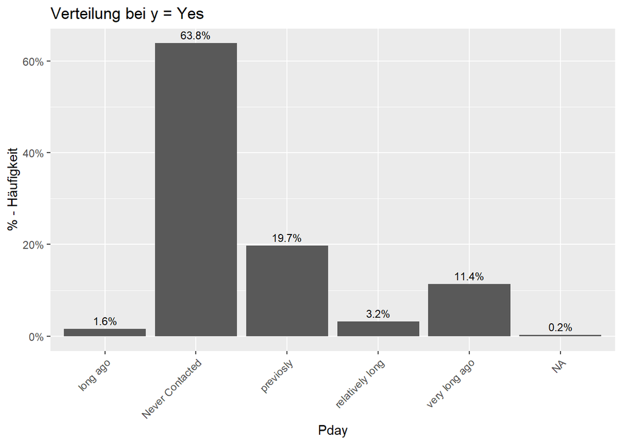

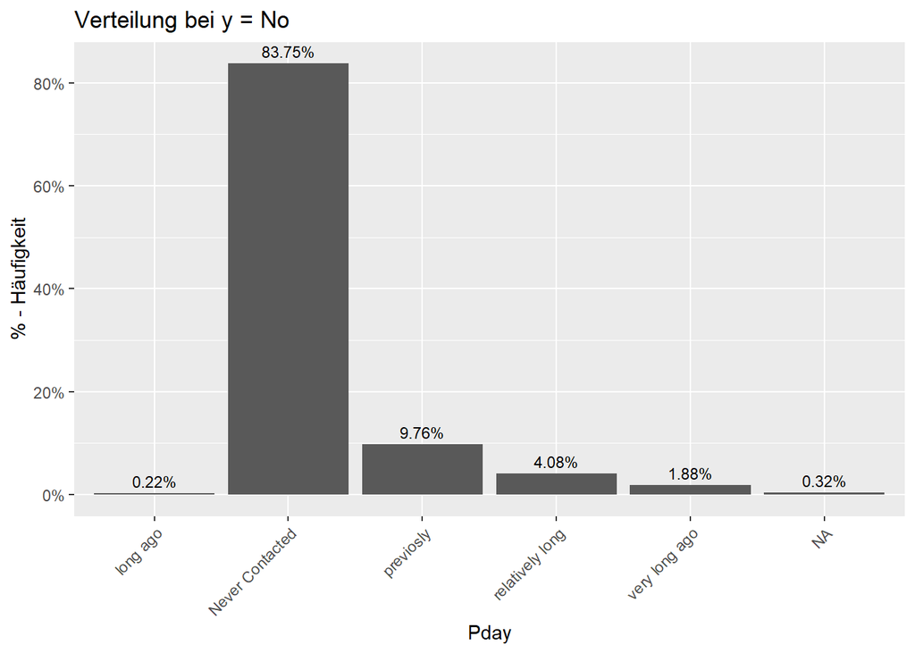

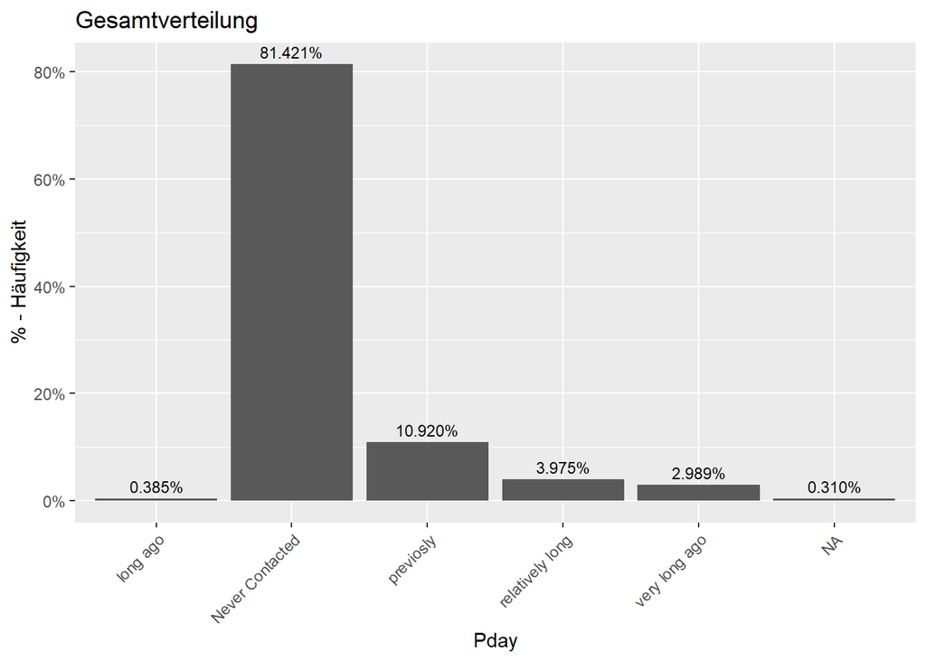

81% der Kunden wurden vorher noch nicht kontaktiert, was diese Variable sehr Merkwürdig erscheinen lässt. Der NA-Anteil hingegen ist nicht sehr hoch. Man kann jedoch davon ausgehen, dass ein Kunde der relativ lange nicht Kontaktiert wurde eher einen Kredit aufnehmen wird, als ein Kunde, der vor kurzem erst Kontatkiert wurde.

### Poutcome-Variable

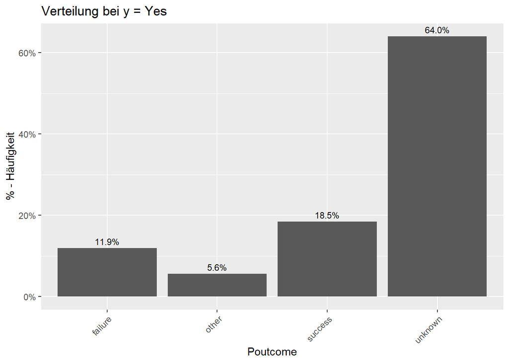

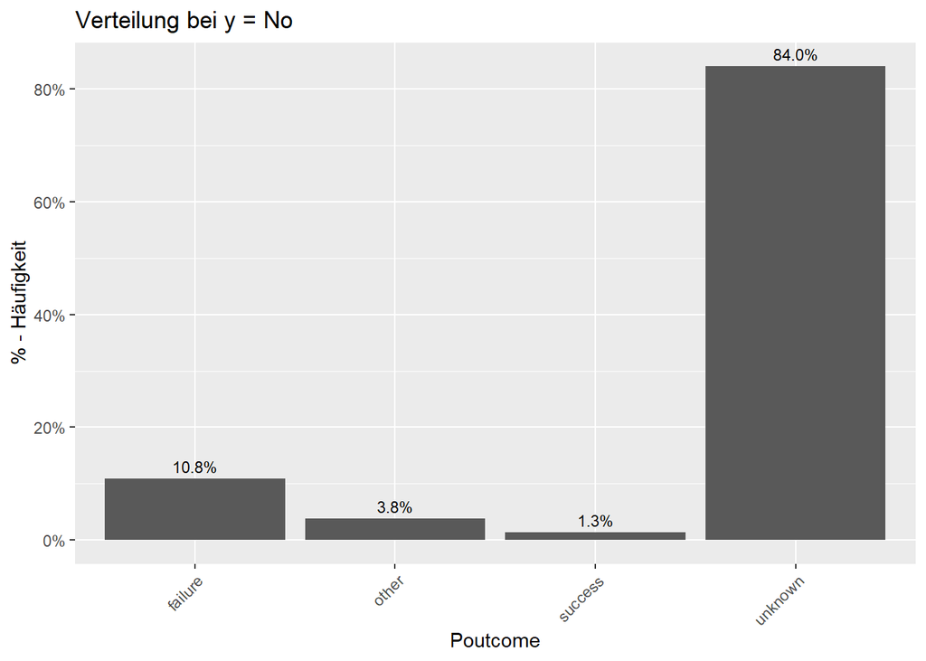

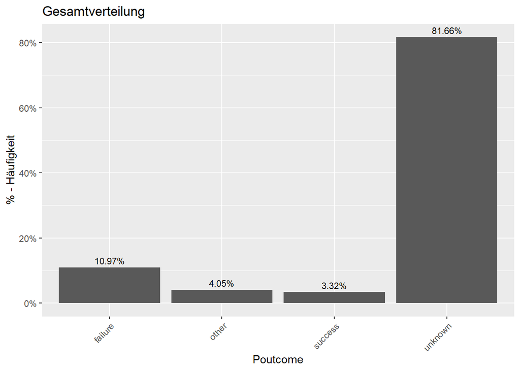

Die unknown Variable ist sehr hoch, doch befor wir diese NA setzen sollten wir uns die anderen p-Variablen im Verhältnis anschauen da wir daraus evt. informationen entziehen können, den sowoh “other” als auch “unknown” können fehlende Werte bei dieser eigentlich Binaren ausprägung.

Dadurch, das jede “Prevois Outcome” Variable mit “unknown” auch keine vorherige kontaktanfrage aus der “pdays” Variable gegenübersteht, sowie das es noch keinen kontakt mit diesem Kunkden vor der Campanie gab (Previos Variable), kann man davon ausgehen, dass Unknown dafür steht, das es vorher noch keine Campain mit diesem Kunden gab.

Demzufolge bin ich davon ausgegangen, das “other” für fehlende Werte steht.

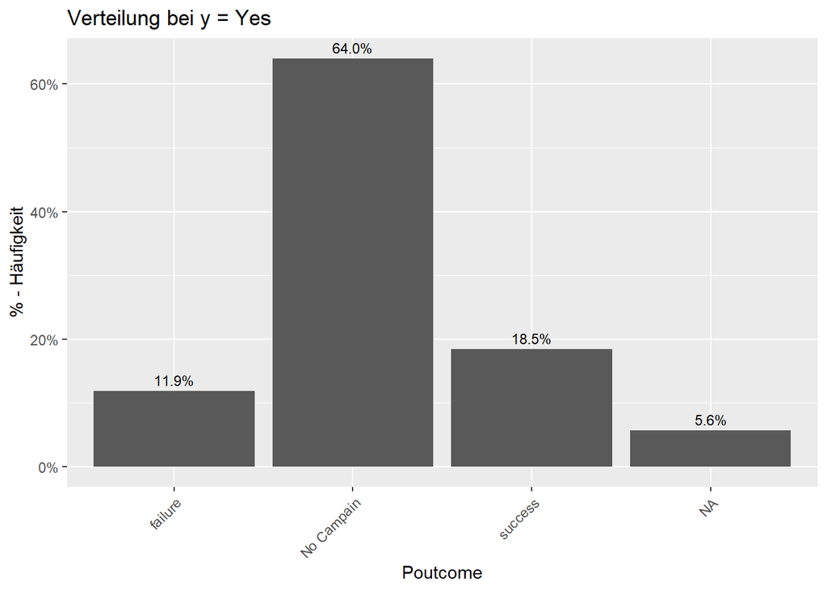

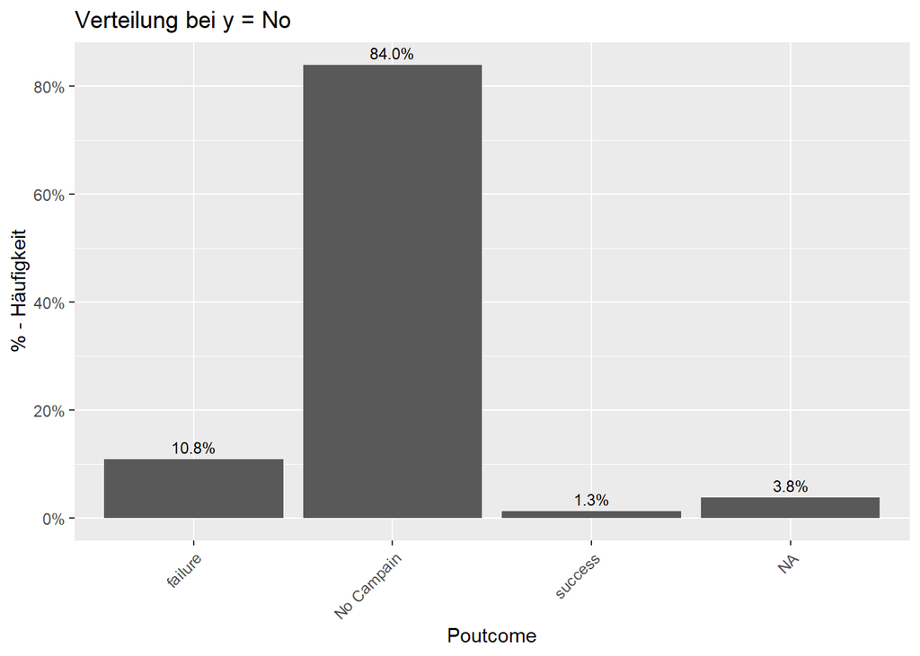

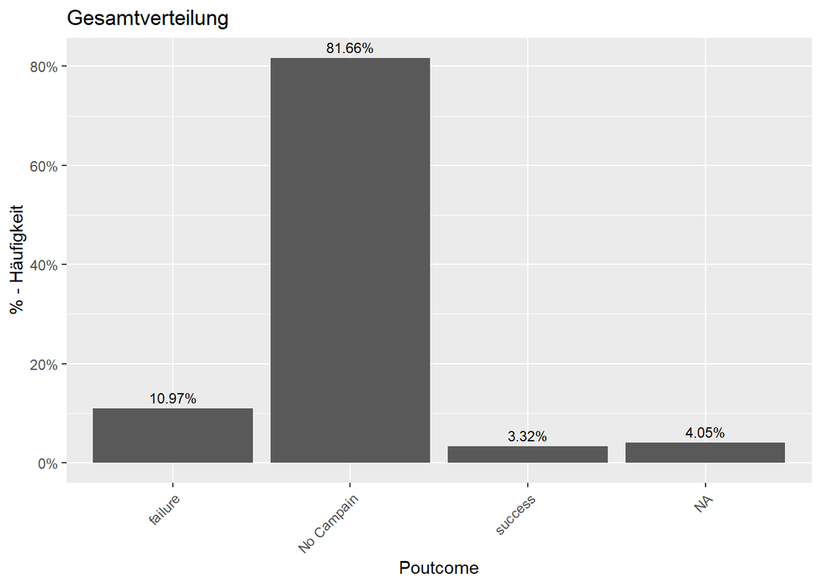

Der NA-Anteil liegt nun bei ca. 4% was nicht besonders Segnifikant ist.

## Grafische Analyse: Metrische Variablen (Integer)

### Age-Variable

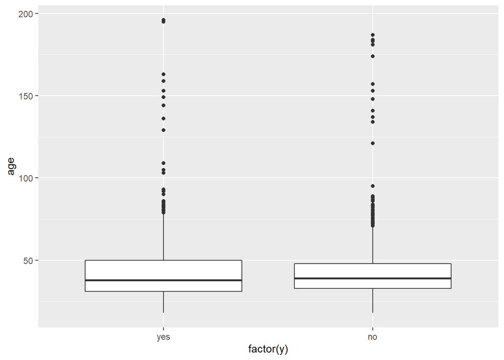

```
## [1] "NA-Anteil:"        "0.103861223458038"
```

Relativ großer NA Anteil Da Kunden mit einem Alter von unter 18 und über 90 unrealistisch sind, entfernen wir diese Werte

```r
df = anti_join(df,data.frame(filter(df, df$age < 18)))
df = anti_join(df,data.frame(filter(df, df$age > 90)))
```

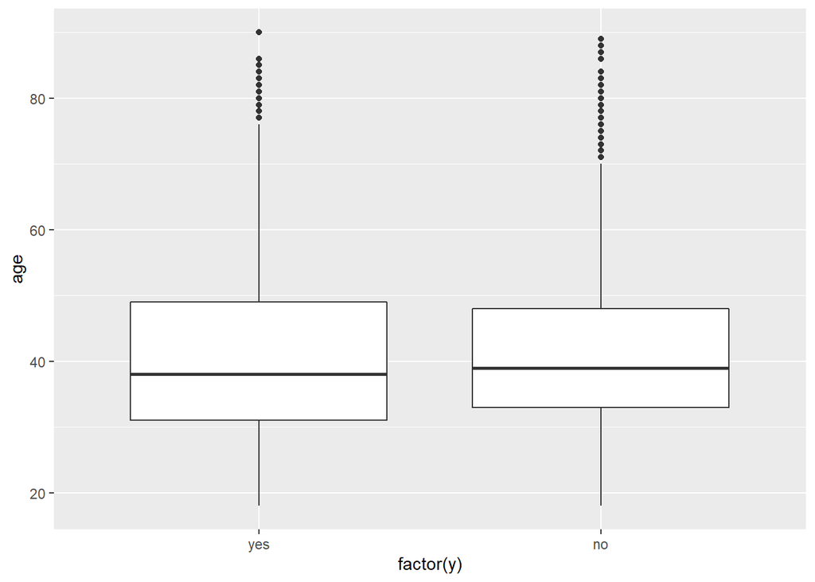

```
## [1] "NA-Anteil:"        "0.103953194180898"
```

Dies hat einen relativ großen Anteil der Ausreißer enfernt. Jedoch sind nach wie vor ca. 10 der Variablen NA (relativ hoher Anteil)

### Balance-Variable

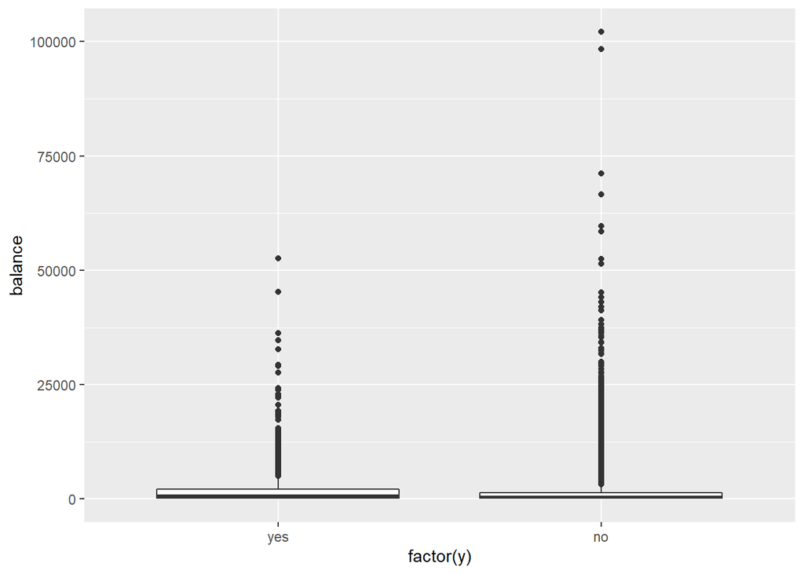

```
## [1] "NA-Anteil:"          "0.00309930423782416"
```

Ziemlich viele leute haben ein sehr Geringes einkommen angegeben. Kaum Werte sind NA, sollte bei der Imputation kein Problem darstellen.

### Campain-Variable

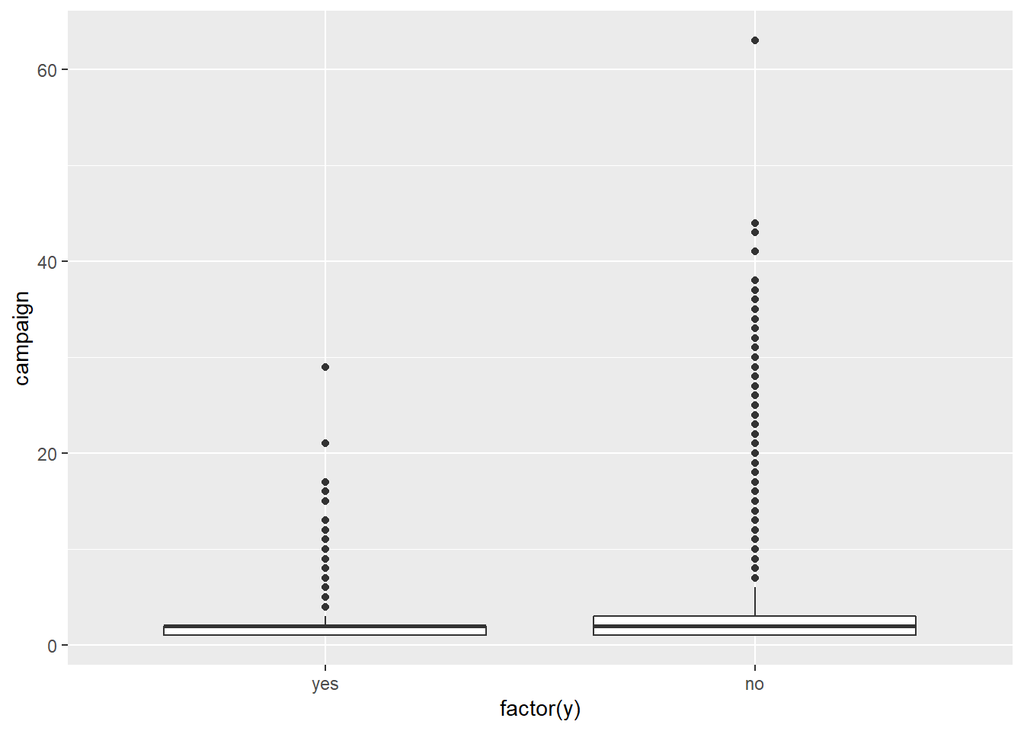

```
## [1] "NA-Anteil:"          "0.00309930423782416"
```

Kaum Werte sind NA, sollte bei der Imputation kein Problem darstellen.

### Previos-Variable

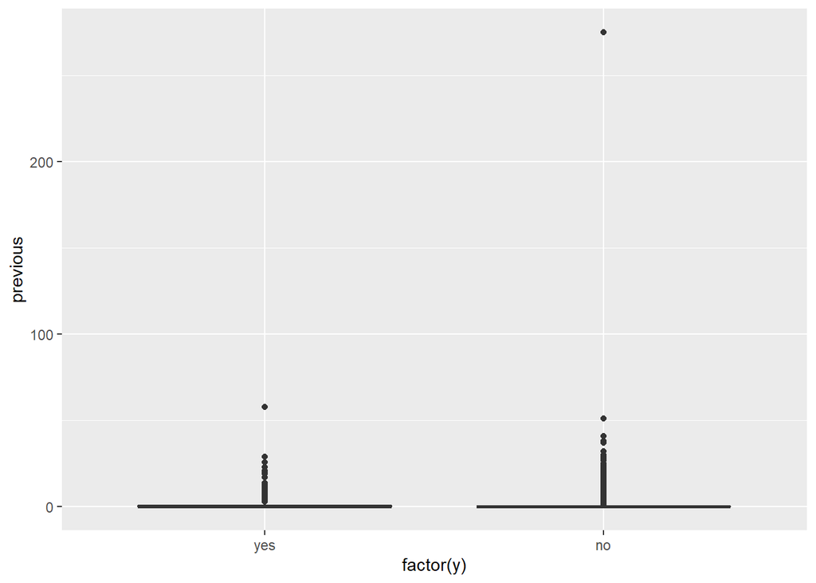

```
## [1] "NA-Anteil:" "0"
```

Enthält einen sehr großen Ausreißer

#### Analyse des Ausreißers:

Er zeigt nichts weiter ungewöhnliches auf

```
##   age        job marital education default balance housing loan  contact day
## 1  40 management married  tertiary      no     543     yes   no cellular   2
##   month campaign     pdays previous poutcome  y
## 1   feb        2 previosly      275     <NA> no
```

Entfernen des Ausreißers, da einzelne Ausreißer nur das Modell verzerren.

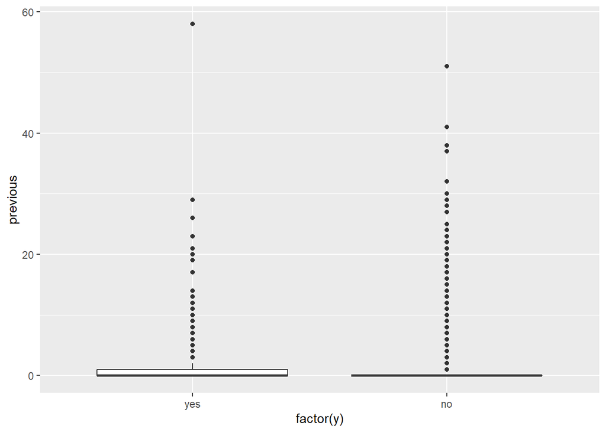

```
## [1] "NA-Anteil:" "0"
```

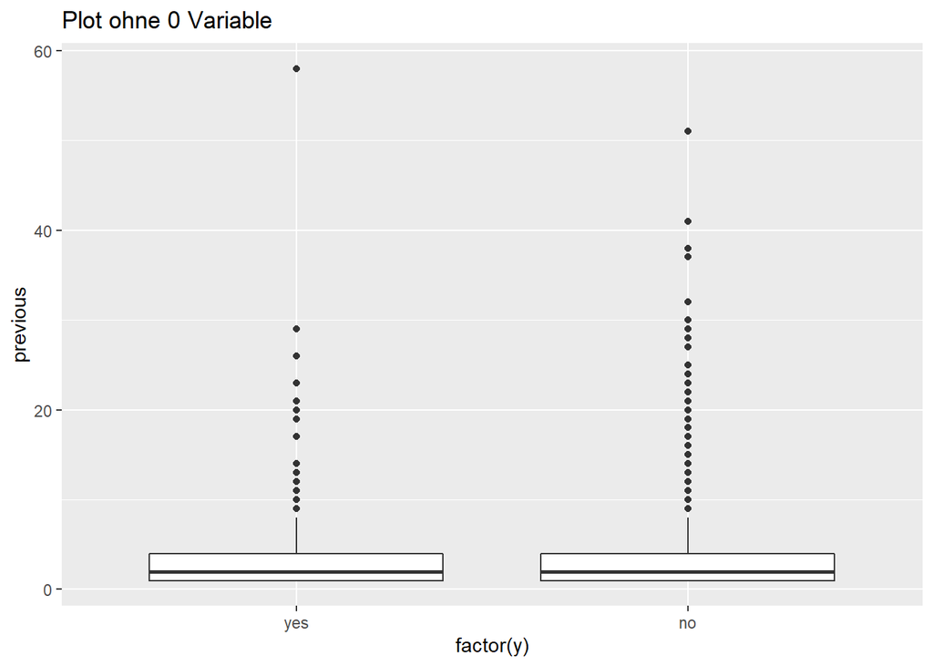

Keine NA-Werte, die Variable zeigt nicht auf, was ungewöhnlich ist, selbst wenn ich alle 0 werte rausfiltere. Das einzige was erkennbar ist, ist dass die Meisten kunden nicht all zu oft Kontaktiert worden sind.

### Korrelation zwischen Metrischen Variablen

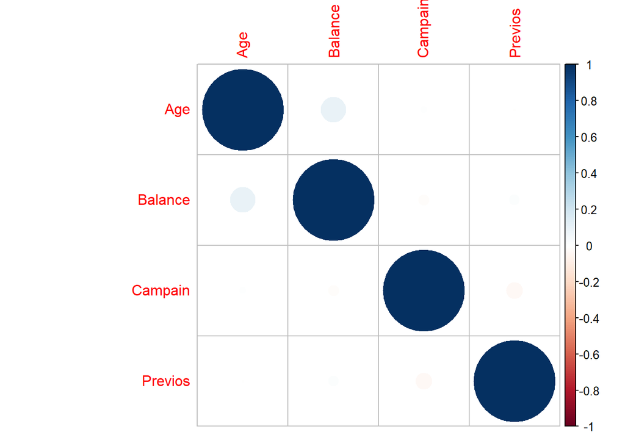

Alle Metrischen Merkmale haben keine segnifikante Korrelation zu einander.

## Imputation fehlender Werte.

Hierzu werde ich den “rf”-Algorithmus aus dem Mice package verwenden.

Zunächst einen überblick über die fehlenden Werte verschaffen.

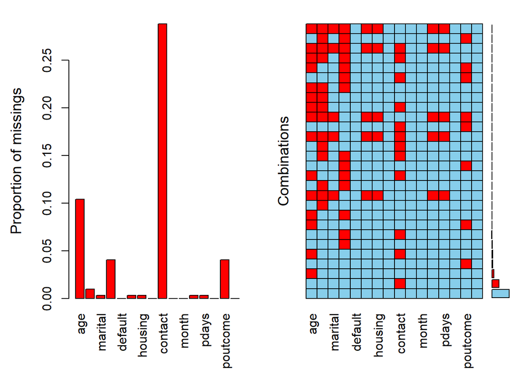

Contact hat wie erwartet den höchsten Anteil an fehlenden Werten.

Zur Imputation verwende ich ein RandomForest verfahren. Desweiteren setzte ich einen seed(12345) um das Ergebnis reproduzierbar zu machen.

```r
set.seed(12345)
InterationCounter = 1
Test = mice(df[,-16],meth = "rf", m=InterationCounter)
```

## Verteilung des Datensatzes in Test und Trainingsdaten:

Zur verteilung der Daten Werde ich ein Stratified Sampling verfahren verwenden, da die Zielvariable sehr ungleich verteilt ist.

```r
df_bereinigt = cbind(complete(Test,1),"y" = df$y)
df_good = df_bereinigt[- grep("no", df_bereinigt$y),]

df_bad = df_bereinigt[-grep("yes",df_bereinigt$y),]

df_train_good = sample_frac(df_good,0.7)
df_train_bad = sample_frac(df_bad,0.7)

df_train = full_join(df_train_good,df_train_bad)
df_test = anti_join(df_bereinigt, df_train)
```

```
## Verteilung Traindaten
```

```
##
##       yes        no
## 0.1167435 0.8832565
```

```
## Verteilung Testdaten
```

```
##
##       yes        no
## 0.1167475 0.8832525
```

```
## Verteilung des Ganzen Datensatzes
```

```
##
##       yes        no
## 0.1167336 0.8832664
```

### Analyse des Datensatzes vor und nach der Imputation:

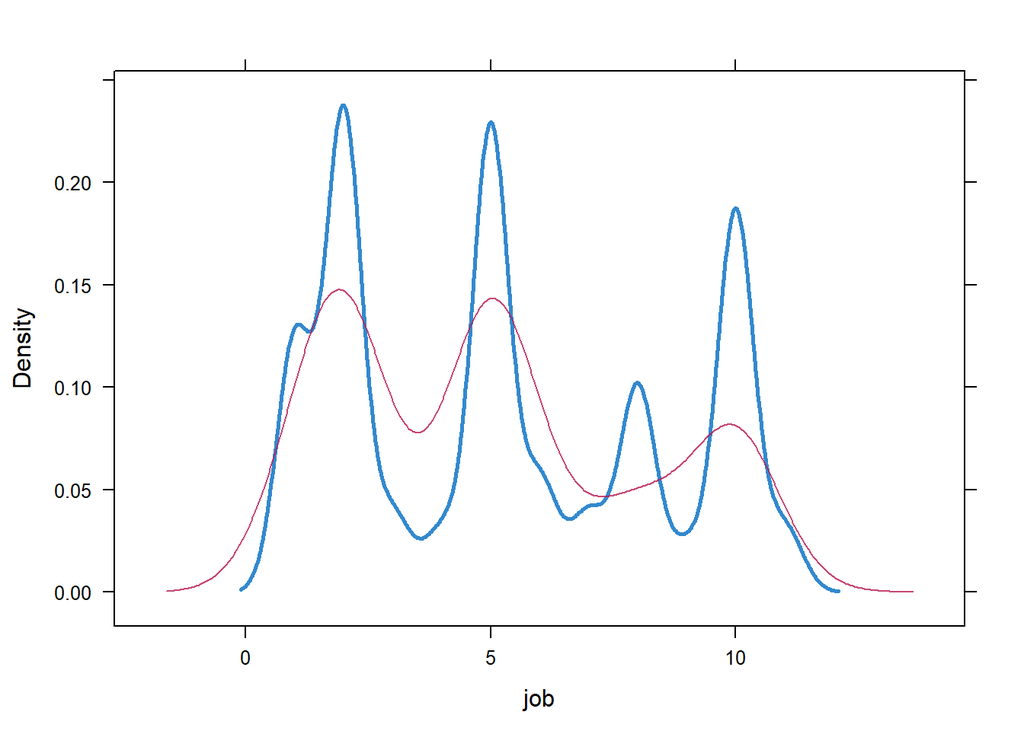

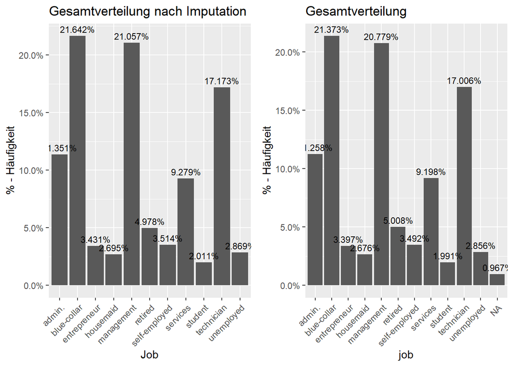

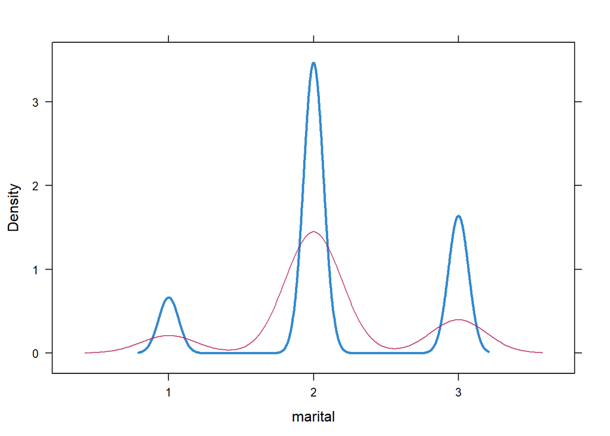

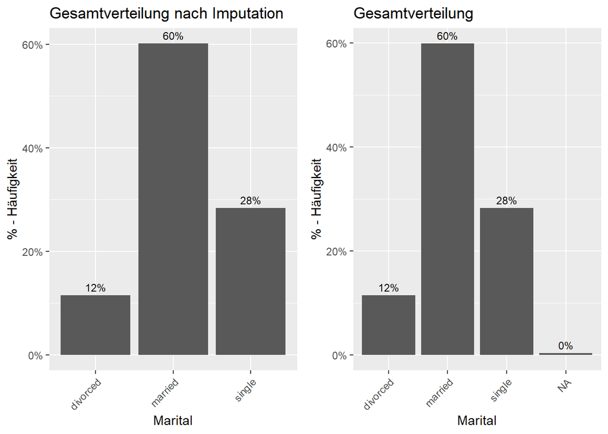

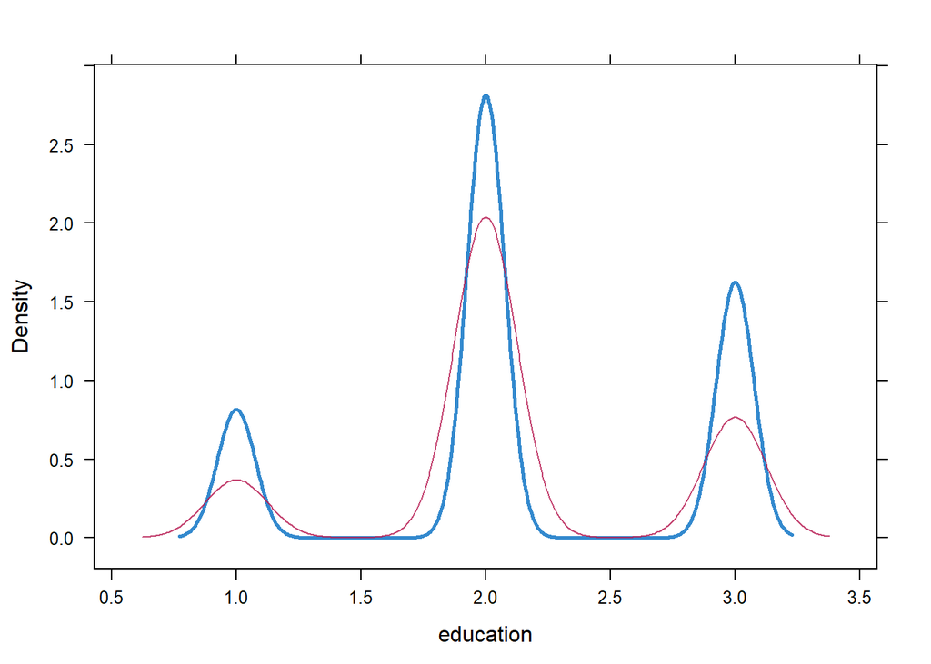

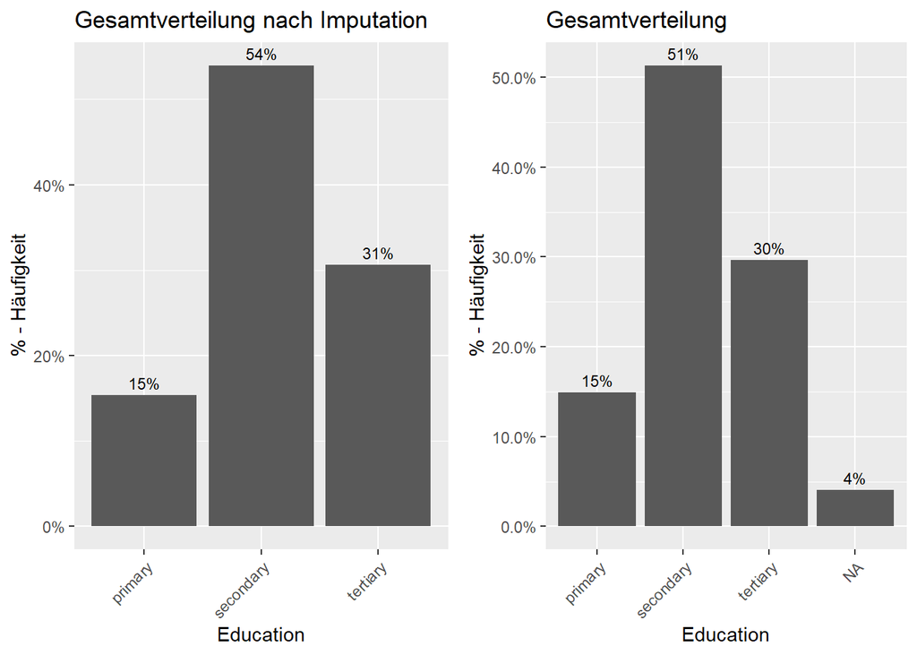

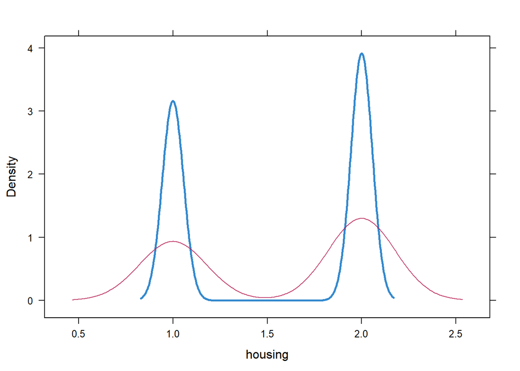

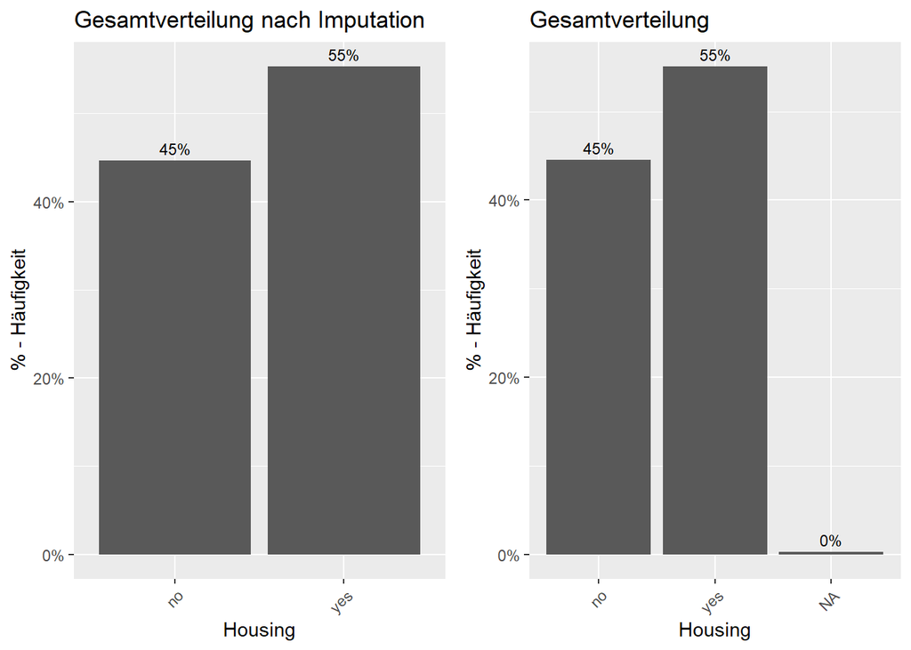

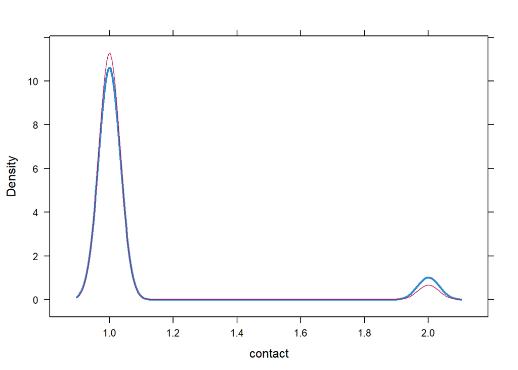

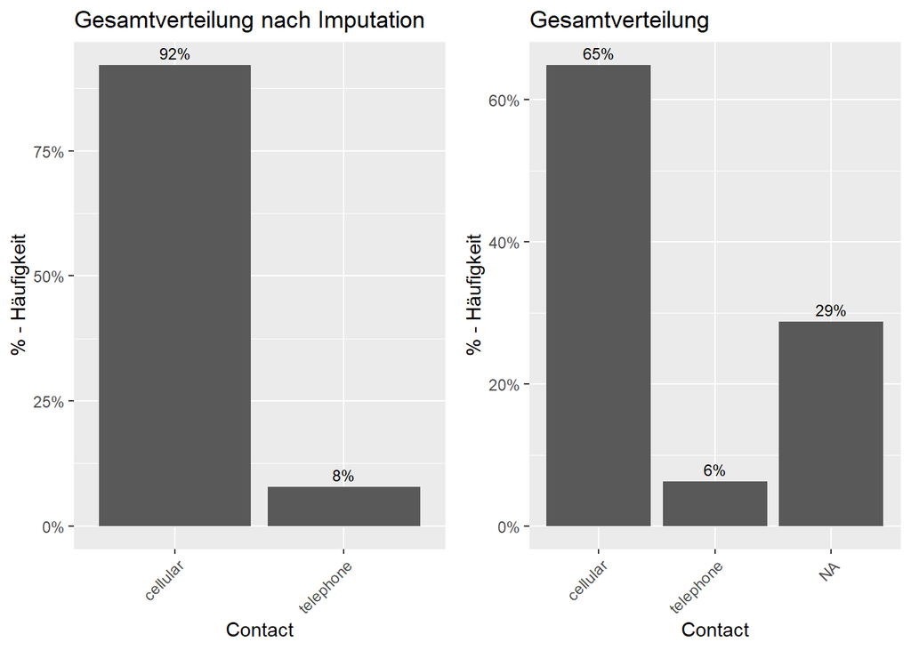

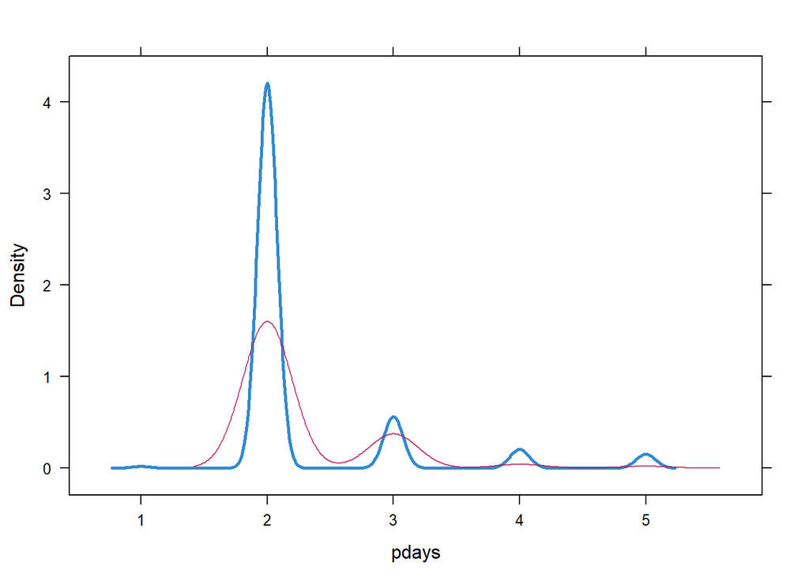

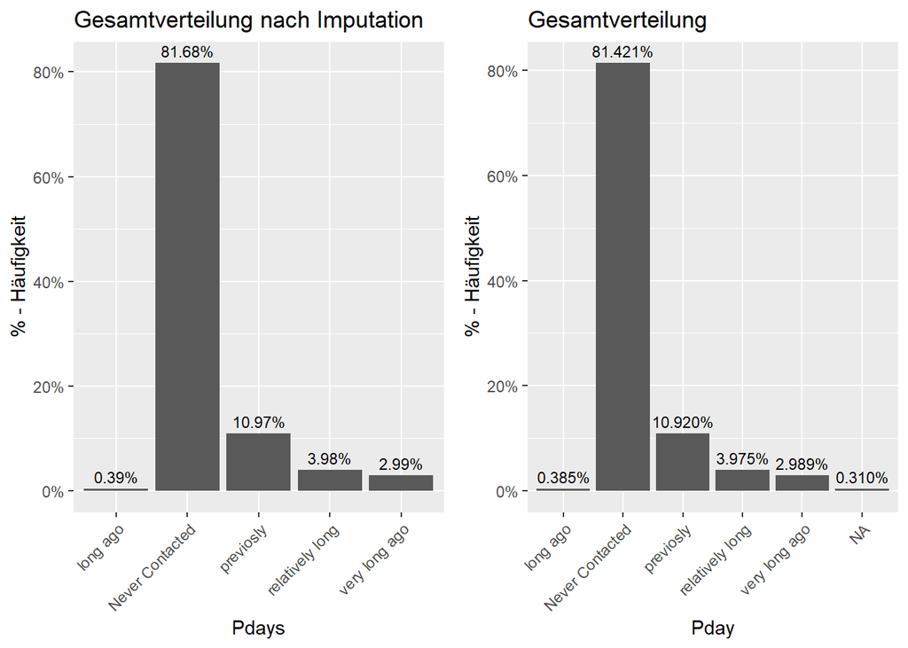

[2 more figures not shown]

```
## [1] "Age-Variable"
```

```
##    Min. 1st Qu.  Median    Mean 3rd Qu.    Max.    NA's
##   18.00   33.00   39.00   40.88   48.00   90.00    3287
```

```
##    Min. 1st Qu.  Median    Mean 3rd Qu.    Max.
##    18.0    33.0    39.0    40.8    48.0    90.0
```

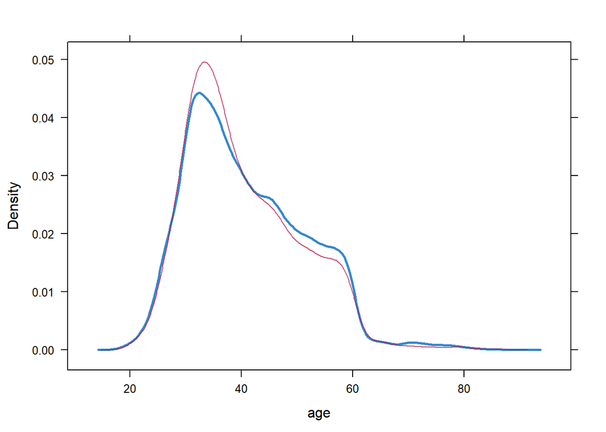

```
## [1] "Balance-Variable"
```

```
##    Min. 1st Qu.  Median    Mean 3rd Qu.    Max.    NA's
##       0     134     483    1411    1433  102127      98
```

```
##    Min. 1st Qu.  Median    Mean 3rd Qu.    Max.
##       0     133     482    1411    1430  102127
```

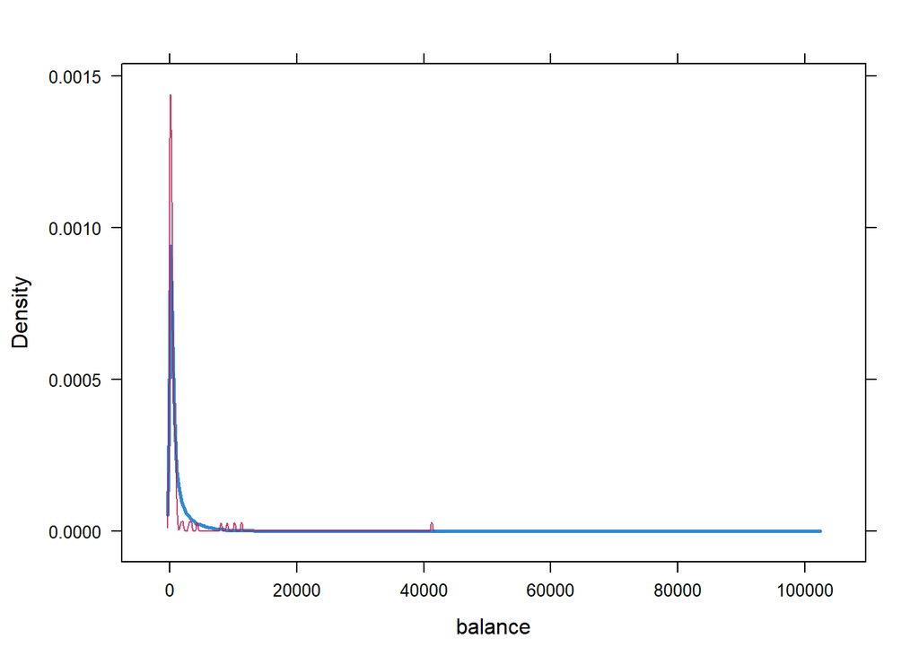

```
## [1] "Campain-Variable"
```

```
##    Min. 1st Qu.  Median    Mean 3rd Qu.    Max.    NA's
##   1.000   1.000   2.000   2.766   3.000  63.000      98
```

```
##    Min. 1st Qu.  Median    Mean 3rd Qu.    Max.
##   1.000   1.000   2.000   2.764   3.000  63.000
```

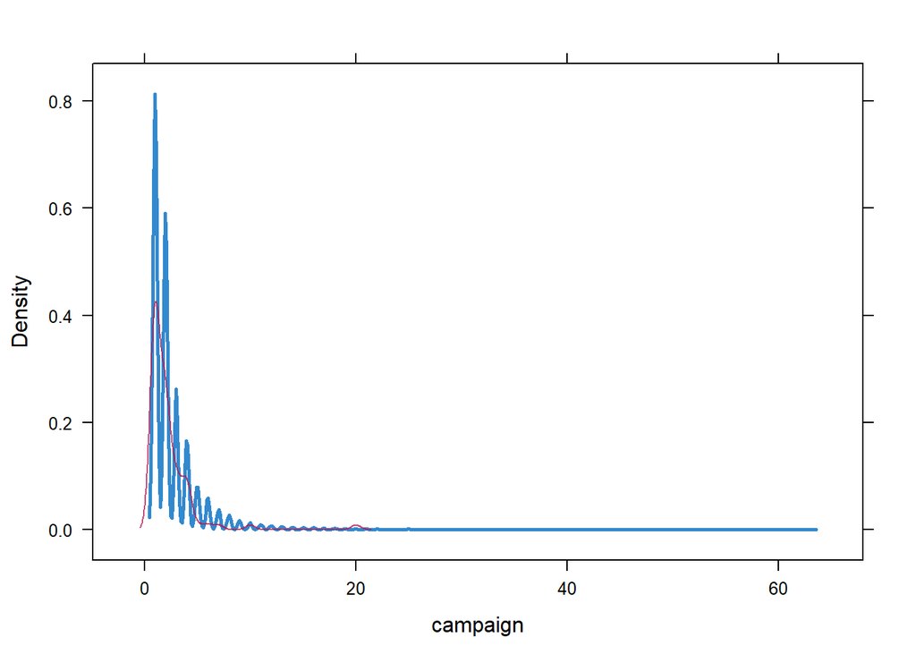

### Überprüfung der Korrelation zu einander

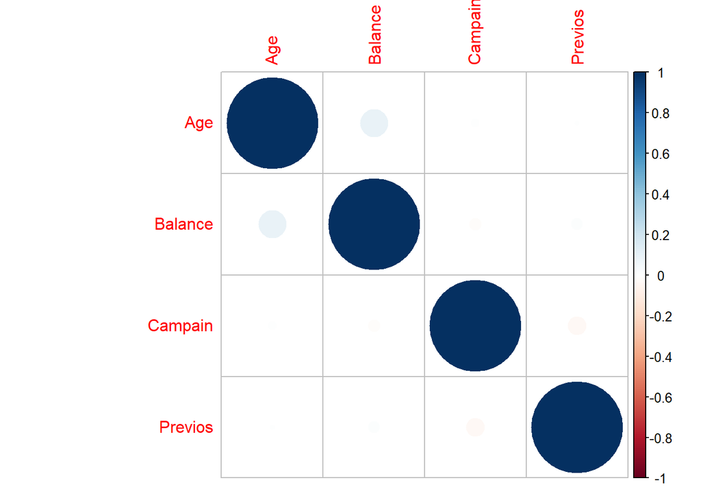

## Entwicklung eines RandonForest Models:

Da wir nun einen geeigneten Trainingsdatensatz, so wie einen Testdatensatz haben können wir ein Model entwickeln und dieses Tunen.

Zum Tuning nutze ich die F1 - Variable, welche das harmonische mittel zwishcen Precision und Recall darstellt.

```r
set.seed(123456)
f1 <- function (data, lev = NULL, model = NULL) {
  precision <- caret::posPredValue(data$pred, data$obs)
  names(precision) = "Precision"
  print(precision)
  recall  <- caret::sensitivity(data$pred, data$obs)
  names(recall) = "Recall"
  print(recall)
  f1_val <- (2 * precision * recall) / (precision + recall)
  names(f1_val) <- c("F1")
  print(f1_val)
}



trainctrl = trainControl(method = "cv", number = 10, verboseIter = FALSE, allowParallel = TRUE, classProbs = TRUE, savePredictions = "all")


myGrid = expand.grid(mtry = c(.mtry = seq(from = 2, to = 15, by = 1)))

RF_Caret_Model_Train = train(y~.,
                       data = df_train,
                       method = "rf",
                       metric = "F1",
                       tuneGrid = myGrid,
                       trControl = trainControl(summaryFunction = f1,
                                                classProbs = TRUE, method = "cv", number = 10, verboseIter = TRUE, search = "grid"))



myGrid = RF_Caret_Model_Train$bestTune

RF_Caret_Final = train(y~.,
                       data = df_train,
                       method = "rf",
                       trControl = trainctrl,
                       tuneGrid = myGrid,
                       seeds = RF_Caret_Model_Train$control$seeds)
```

Als nächstes Optimieren wir den Cutoff

```r
Cutoff_RF <- thresholder(RF_Caret_Final,
                              threshold = seq(.005, 1, by = 0.005),
                              final = TRUE)

Full_Frame_RF = Cutoff_RF[which.max(Cutoff_RF$F1),]
Full_Frame_RF$prob_threshold
```

```
## [1] 0.245
```

Nun, da das Modell Fertig getuned wurde können wir dieses evaluieren.

Nun wenden wir das Modell auf unseren erstellten Testdatensatz an und Evaluieren das Modell.

### Confusionsmatrix

```r
ModelTest = predict(RF_Caret_Final, df_test, type = "prob")
threshold <- Full_Frame_RF$prob_threshold
pred      <- factor( ifelse(ModelTest["yes"] > threshold, "yes", "no") )

confusionMatrix(reference = df_test$y,  data = pred, mode = "prec_recall", positive="yes")
```

```
## Confusion Matrix and Statistics
##
##           Reference
## Prediction  yes   no
##        yes  506  670
##        no   601 7705
##
##                Accuracy : 0.866
##                  95% CI : (0.8589, 0.8728)
##     No Information Rate : 0.8833
##     P-Value [Acc > NIR] : 1.00000
##
##                   Kappa : 0.3672
##
##  Mcnemar's Test P-Value : 0.05647
##
##               Precision : 0.43027
##                  Recall : 0.45709
##                      F1 : 0.44328
##              Prevalence : 0.11675
##          Detection Rate : 0.05336
##    Detection Prevalence : 0.12402
##       Balanced Accuracy : 0.68855
##
##        'Positive' Class : yes
##
```

Ich habe mich hier entschlossen den Cutoff in anbetracht zu Precision und Recall zu optimieren, je nach anwendungsfall ist es evt. besser diesen mehr nach Recall oder Precision zu richten. Da ich hier keine Opportunitätskosten angestzt habe gehe ich von diesem Ergebnis aus.

Unser Modell sieht ziemlich gut aus, wenn man davon ausgeht, dass hohe oportunitätskosten herrschen.

Nun Plotten wir unser Ergebnis:

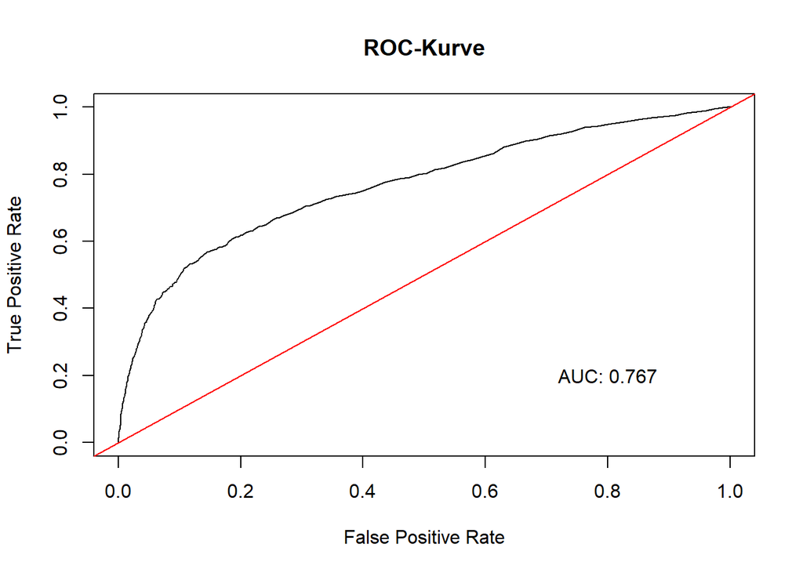

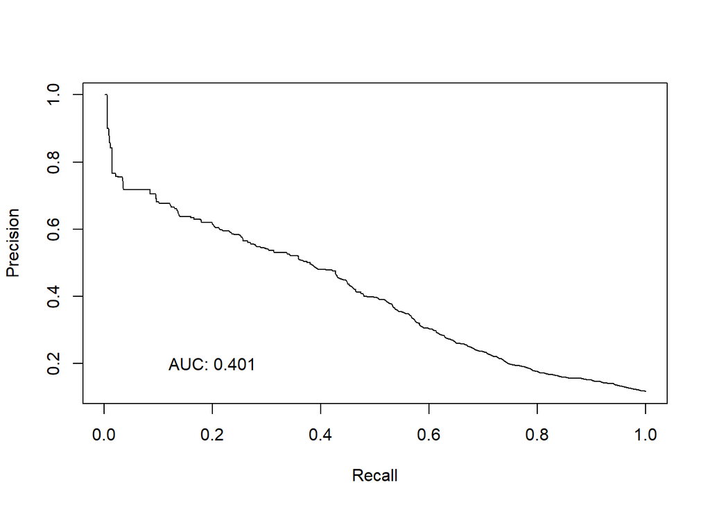

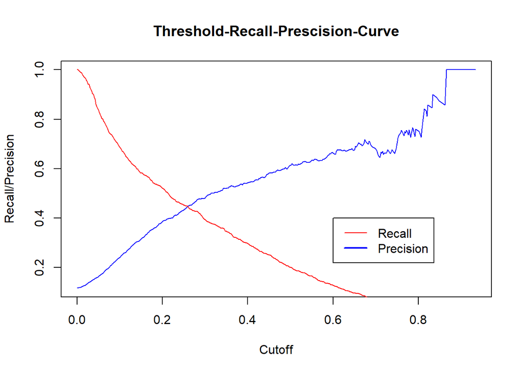

### Entwicklung eines Logistischen Regression Models:

Zunächst generieren wir eine normale Logistische Regression auf den Daten.

Dannach werden wir die Daten Mittels einer Elastischen Regression (verbindung zwischen Lasso (L1) und Ridge Regession (L2)) regulieren und darauf eine Logistische Regression anwenden.

#### Normale Logistische Regression:

```r
#Normal Logistic Regression
set.seed(123456)
Log_Reg_Normal = train(y~.,
                data = df_train,
                method = "glm",
                family = "binomial",
                metric = "F1",
                trControl = trainControl(method = "cv", number = 10,summaryFunction = f1, classProbs = TRUE, savePredictions = "all"), #,
                )
```

Anwendung einer Elastischen Regression

```r
#Regulized Logstic Regresion
set.seed(123456)
Log_Reg_Regulized = train(y~.,
                data = df_train,
                method = "glmnet",
                family = "binomial",
                metric = "F1",
                trControl = trainControl(method = "cv", number = 10, summaryFunction = f1, classProbs = TRUE, savePredictions = "all"), #
                )
```

Evaluieren der Beiden Modelle

```
## [1] "Logistische Regression:"
```

```
## Confusion Matrix and Statistics
##
##           Reference
## Prediction  yes   no
##        yes  185  131
##        no   922 8244
##
##                Accuracy : 0.8889
##                  95% CI : (0.8825, 0.8952)
##     No Information Rate : 0.8833
##     P-Value [Acc > NIR] : 0.0428
##
##                   Kappa : 0.2195
##
##  Mcnemar's Test P-Value : <2e-16
##
##               Precision : 0.58544
##                  Recall : 0.16712
##                      F1 : 0.26001
##              Prevalence : 0.11675
##          Detection Rate : 0.01951
##    Detection Prevalence : 0.03333
##       Balanced Accuracy : 0.57574
##
##        'Positive' Class : yes
##
```

```
## [1] "Elastische Regression:"
```

```
## Confusion Matrix and Statistics
##
##           Reference
## Prediction  yes   no
##        yes  181  124
##        no   926 8251
##
##                Accuracy : 0.8893
##                  95% CI : (0.8828, 0.8955)
##     No Information Rate : 0.8833
##     P-Value [Acc > NIR] : 0.03465
##
##                   Kappa : 0.2169
##
##  Mcnemar's Test P-Value : < 2e-16
##
##               Precision : 0.59344
##                  Recall : 0.16350
##                      F1 : 0.25637
##              Prevalence : 0.11675
##          Detection Rate : 0.01909
##    Detection Prevalence : 0.03217
##       Balanced Accuracy : 0.57435
##
##        'Positive' Class : yes
##
```

Wie wir sehen können, ist die Logistische Regression besser als die Elastische, jedoch nicht viel unterschied. Was keine große verwunderung ist, da alpha und lambda beide auf einem sehr geringen Wert gehalten wurden und somit kaum einfluss auf die Funktion hatte.

### Cutoff anpassen

```r
Cutoff_LRG <- thresholder(Log_Reg_Normal,
                              threshold = seq(.005, 1, by = 0.005),
                              final = TRUE)

Full_Frame_Reg = Cutoff_LRG[which.max(Cutoff_LRG$F1),]
Full_Frame_Reg$prob_threshold
```

```
## [1] 0.19
```

Modell auf Testdaten anwenden und evaluieren.

```r
LGR_Predict = predict(Log_Reg_Regulized, df_test, type = "prob")
threshold <- Full_Frame_Reg$prob_threshold
pred      <- factor( ifelse(LGR_Predict["yes"] > threshold, "yes", "no") )

confusionMatrix(reference = df_test$y,  data = pred, mode = "prec_recall", positive="yes")
```

```
## Confusion Matrix and Statistics
##
##           Reference
## Prediction  yes   no
##        yes  484  607
##        no   623 7768
##
##                Accuracy : 0.8703
##                  95% CI : (0.8634, 0.877)
##     No Information Rate : 0.8833
##     P-Value [Acc > NIR] : 1.0000
##
##                   Kappa : 0.367
##
##  Mcnemar's Test P-Value : 0.6689
##
##               Precision : 0.44363
##                  Recall : 0.43722
##                      F1 : 0.44040
##              Prevalence : 0.11675
##          Detection Rate : 0.05104
##    Detection Prevalence : 0.11506
##       Balanced Accuracy : 0.68237
##
##        'Positive' Class : yes
##
```

Auch hier habe ich mich wieder dazu entschlossen den Cutoff nach Precision und Recall in gleicher Geweichtung zu optimieren.

### Plotten der Kurven der Elastischen Regression

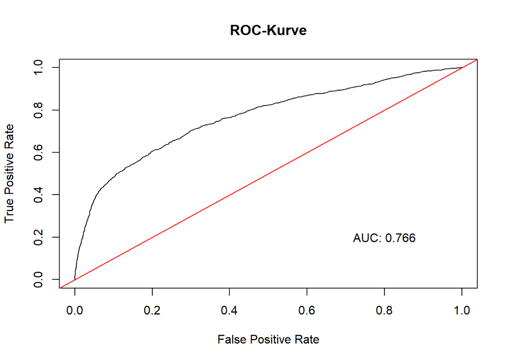

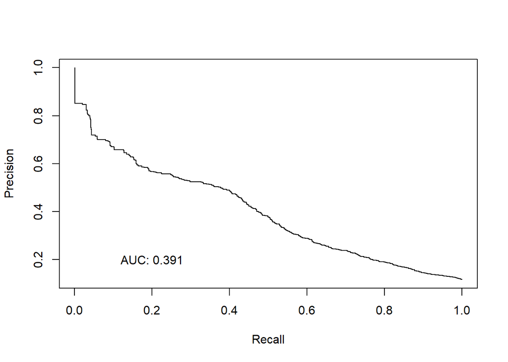

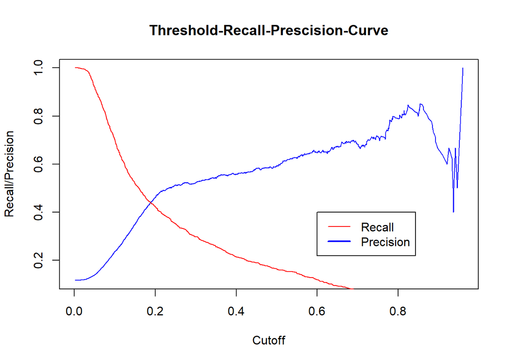

### Bereitstellung des zu Prognostizierenden Datensatzes

Im anschluss habe ich alle umformungsschritte des ersten Datensatzes auch auf den zu prognostizierenden Angewnd.

```r
df_Dont_use[df_Dont_use==""] = NA #Leerstrings mit NA ersetzen
df_Dont_use$marital = factor(df_Dont_use$marital) #entfernen des leeren levels
df_Dont_use$housing = factor(df_Dont_use$housing) #entfernen des leeren levels

df_Dont_use$age = as.integer(df_Dont_use$age) #Umformatierung in Numeric
df_Dont_use$age = abs(df_Dont_use$age) #Negatives Alter kann nicht existieren

df_Dont_use$balance = as.integer(df_Dont_use$balance) #Umformatierung in Numeric
df_Dont_use$balance = abs(df_Dont_use$balance) #Negatives verfügbares einkommen ist unrealistisch

df_Dont_use$campaign = as.integer(df_Dont_use$campaign) #Umformatierung in Numeric
df_Dont_use$campaign = abs(df_Dont_use$campaign) #Man keinen einen Kunden nicht negativ oft kontaktieren.

df_Dont_use$pdays = as.numeric(df_Dont_use$pdays) #Umformatierung in Numeric

df_Dont_use$previous = as.integer(df_Dont_use$previous) #Umformatierung in Numeric
df_Dont_use$previous = abs(df_Dont_use$previous) #Man keinen einen Kunden nicht negativ oft kontaktieren.

df_Dont_use$day = as.factor(df_Dont_use$day) #Ein Monat kann nur bis zu 31 Tage haben, demzufolge ist ein Factor am Sinnfollsten.

df_Dont_use$y = factor(df_Dont_use$y, levels = c("yes","no"))

#---------------------------

df_Dont_use$job[df_Dont_use$job=="unknown"] = NA #Alle unknown NA setzen
df_Dont_use$job = factor(df_Dont_use$job) #Leeres level entfernen

#------------------------------

df_Dont_use$education[df_Dont_use$education=="unknown"] = NA
df_Dont_use$education = factor(df_Dont_use$education)

#------------------------------

df_Dont_use$contact[df_Dont_use$contact=="unknown"] = NA
df_Dont_use$contact = factor(df_Dont_use$contact)

#---------------------------------

df_Dont_use$day[df_Dont_use$day==32] = 1
df_Dont_use$day = factor(df_Dont_use$day)

#--------------------------------------------

df_Dont_use$pdays[df_Dont_use$pdays==-1] = "Never Contacted"
df_Dont_use$pdays[df_Dont_use$pdays<33] = "previosly"
df_Dont_use$pdays[df_Dont_use$pdays<39] = "relatively long"
df_Dont_use$pdays[df_Dont_use$pdays<48] = "long ago"
df_Dont_use$pdays[df_Dont_use$pdays<=99] = "very long ago"
df_Dont_use$pdays = as.factor(df_Dont_use$pdays)

#---------------------------------------------

df_Dont_use$poutcome = as.character(df_Dont_use$poutcome)
df_Dont_use$poutcome[df_Dont_use$poutcome=="unknown"] = "No Campain"
df_Dont_use$poutcome[df_Dont_use$poutcome=="other"] = NA
df_Dont_use$poutcome = as.factor(df_Dont_use$poutcome)

#---------------------------------------------
summary(df_Dont_use)
```

```
##       age                  job           marital         education
##  Min.   : 18.00   blue-collar:2936   divorced:1546   primary  :2118
##  1st Qu.: 33.00   management :2845   married :8167   secondary:6956
##  Median : 39.00   technician :2181   single  :3795   tertiary :3921
##  Mean   : 41.04   admin.     :1587   NA's    :  55   NA's     : 568
##  3rd Qu.: 49.00   services   :1237
##  Max.   :197.00   (Other)    :2642
##  NA's   :1249     NA's       : 135
##  default        balance      housing      loan            contact
##  no :13335   Min.   :    0   no  :5902   no :11428   cellular :8738
##  yes:  228   1st Qu.:  145   yes :7606   yes: 2135   telephone: 918
##              Median :  489   NA's:  55               NA's     :3907
##              Mean   : 1416
##              3rd Qu.: 1448
##              Max.   :81204
##              NA's   :55
##       day           month         campaign                  pdays
##  20     : 817   may    :4074   Min.   : 1.000   long ago       :   48
##  18     : 677   jul    :2062   1st Qu.: 1.000   Never Contacted:11065
##  17     : 586   aug    :1836   Median : 2.000   previosly      : 1486
##  21     : 576   jun    :1640   Mean   : 2.765   relatively long:  513
##  28     : 570   nov    :1159   3rd Qu.: 3.000   very long ago  :  396
##  14     : 569   apr    : 891   Max.   :58.000   NA's           :   55
##  (Other):9768   (Other):1901   NA's   :55
##     previous             poutcome        y
##  Min.   : 0.0000   failure   : 1430   yes :    0
##  1st Qu.: 0.0000   No Campain:11114   no  :    0
##  Median : 0.0000   success   :  460   NA's:13563
##  Mean   : 0.5717   NA's      :  559
##  3rd Qu.: 0.0000
##  Max.   :55.0000
##
```

```r
set.seed(12345)
InterationCounter = 1
Test = mice(df_Dont_use[,-16],meth = "rf", m=InterationCounter)
df_Dont_use = cbind(complete(Test,1),"y" = df_Dont_use$y)
```

### Anwendung des RandomForest Modells

Da das RandomForest Model bessere Ergebnisse als die Logistische Regression für mich aufgewiesen hat, werde ich dieses im folgenden auf die zu prognostizierenden Daten Anwenden.

```r
RF_Predict = predict(RF_Caret_Final, df_Dont_use, type = "prob")
threshold <- Full_Frame_RF$prob_threshold
pred_RF      <- factor( ifelse(RF_Predict["yes"] > threshold, "yes", "no") )
```

```r
Final_DF_Result = pred_RF

ID_Column = read.csv("C:/Users/Alexander/OneDrive - hochschule-trier.de/uni/4. Semester/KIDM/Projekt/Marketing/marketing_dataset_to_predict.csv",sep="§",dec=",",fileEncoding = "UTF-8")[1]

write.csv(cbind(ID_Column,pred_RF),"C:/Users/Alexander/OneDrive - hochschule-trier.de/uni/4. Semester/KIDM/Projekt/Marketing/Prediction RandomForest Alexander Hilberer.csv", row.names=FALSE) # nur ID und prediction.
```